# Lab 6

Author

PSTAT 134/234

## Feature Engineering

For this week’s lab, we’ll take a look at one of the data sets we introduce in PSTAT 131/231 – one of the most commonly practiced with data sets on Kaggle, the Titanic data. Although we do fit some models to the Titanic data in 131/231, the feature engineering we do in that course is relatively limited. If we delve more deeply, we can potentially achieve better model performance.

### Data

As a reminder, the Titanic dataset comes from a Kaggle competition that is constantly running, where many data scientists practice models to hone their skills. You can find a link to the competition [here](https://www.kaggle.com/competitions/titanic). It is a binary classification problem, where the goal is to predict which passengers would survive the [Titanic shipwreck](https://en.wikipedia.org/wiki/Titanic).

The following code loads the data from `data/titanic.csv`. You can familiarize yourself with the variables it contains using the codebook (`data/titanic_codebook.txt`) or with the information below.

```r
library(tidyverse)
library(corrplot)
library(tidymodels)
titanic <- read_csv("data/titanic.csv")
dim(titanic)
```

```
[1] 891  12
```

```r
head(titanic)
```

```
# A tibble: 6 × 12
  passenger_id survived pclass name  sex     age sib_sp parch ticket  fare cabin
         <dbl> <chr>     <dbl> <chr> <chr> <dbl>  <dbl> <dbl> <chr>  <dbl> <chr>
1            1 No            3 Brau… male     22      1     0 A/5 2…  7.25 <NA>
2            2 Yes           1 Cumi… fema…    38      1     0 PC 17… 71.3  C85
3            3 Yes           3 Heik… fema…    26      0     0 STON/…  7.92 <NA>
4            4 Yes           1 Futr… fema…    35      1     0 113803 53.1  C123
5            5 No            3 Alle… male     35      0     0 373450  8.05 <NA>
6            6 No            3 Mora… male     NA      0     0 330877  8.46 <NA>
# ℹ 1 more variable: embarked <chr>
```

```python
import numpy as np
import pandas as pd
import re

import matplotlib.pyplot as plt
import seaborn as sns
sns.set(style="darkgrid")

from sklearn.ensemble import RandomForestClassifier
from sklearn.preprocessing import OneHotEncoder, LabelEncoder, StandardScaler
from sklearn.metrics import roc_curve, auc
from sklearn.model_selection import StratifiedKFold
from sklearn.model_selection import train_test_split

import string
import warnings
warnings.filterwarnings('ignore')

titanic = r.titanic
```

There are $891$ rows and $12$ columns in the dataset. The columns are:

- `passenger_id`: Unique identifier of rows/passengers. Not likely to have any effect on the outcome;
- `survived`: The target variable, a binary variable with values `"Yes"` (passenger survived) or `"No"` (passenger did not survive);
- `pclass`: Socioeconomic status of the passenger, an ordinal feature with three values, `1` = upper class, `2` = middle class, `3` = lower class;
- `name`: Passenger’s full name, last name first;
- `sex`: Passenger sex, a binary variable with values `"male"` and `"female"`;
- `age`: Passenger age in years;
- `sib_sp`: Total number of passengers’ siblings and/or spouses on board;
- `parch`: Total number of passengers’ parents and/or children on board;
- `ticket`: Passengers’ ticket number;
- `fare`: Passengers’ fare;
- `cabin`: Passengers’ cabin number;
- `embarked`: Point of embarkation, a categorical feature with three values, `"C"` = Cherbourg, `"Q"` = Queenstown, `"S"` = Southampton.

### Missing Data

To assess the amount and pattern of missingness in R, we could run:

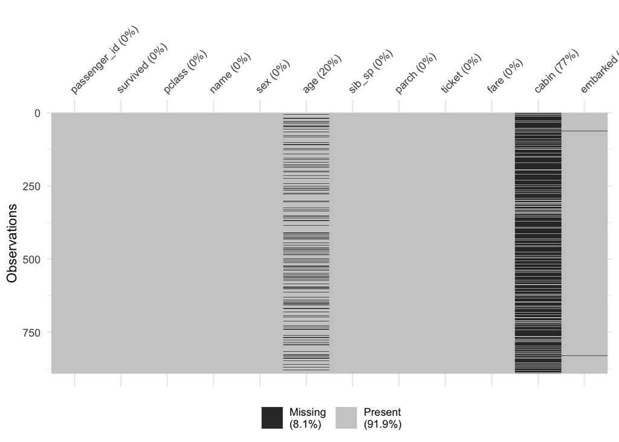

```r
library(naniar)
vis_miss(titanic)
```

This would reveal to us that there are missing values of `age` and `cabin`. Without further investigation, we might not realize that there are also missing values of `embarked`, but there are:

```r
titanic$embarked %>% is.na() %>%
  mean()
```

```
[1] 0.002244669
```

In Python, we could diagnose the number and pattern of missing values:

```python
def display_missing(df):
    for col in df.columns.tolist():
        print('{} column missing values: {}'.format(col, df[col].isnull().sum()))
    print('\n')

display_missing(titanic)
```

```
passenger_id column missing values: 0
survived column missing values: 0
pclass column missing values: 0
name column missing values: 0
sex column missing values: 0
age column missing values: 177
sib_sp column missing values: 0
parch column missing values: 0
ticket column missing values: 0
fare column missing values: 0
cabin column missing values: 687
embarked column missing values: 2
```

#### Age

We will replace missing values of `age` with median imputation, but rather than using the overall median, we’ll replace any missing values with the corresponding median of age for that level of passenger class and sex. In other words, if a first-class male passenger is missing their `age` value, we will replace their missing value with the median age of all other first-class male passengers, and so on.

The reasoning behind this is based on passenger class’s moderate correlation with `age` and `survived` (and because we can logically reason that passenger sex, which also has a strong relationship with survival, might be related as well). To check the correlations:

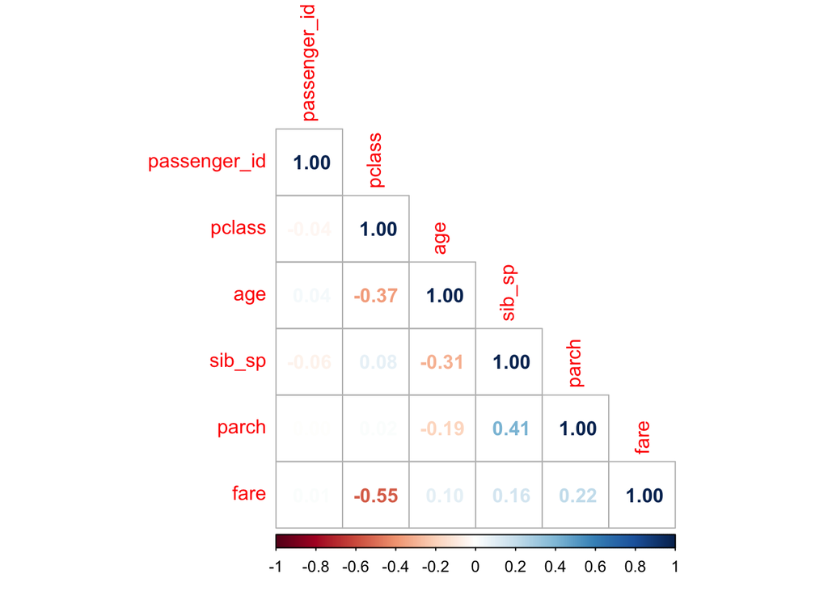

```r
titanic %>%
  select_if(is.numeric) %>%
  cor(use = "pairwise.complete.obs") %>%
  corrplot(type = "lower", method = "number")
```

To do this in R:

```r
titanic <- titanic %>%
  group_by(pclass, sex) %>%
  reframe(age_median = median(age, na.rm = T),
            across(.cols = everything())) %>%
  mutate(age = case_when(
    is.na(age) ~ age_median,
    .default = age
  )) %>%
  select(-age_median)
```

To do this in Python:

```python
age_medians = titanic.groupby(['pclass', 'sex'])['age'].transform(lambda x: x.fillna(x.median()))

titanic['age'] = titanic['age'].fillna(age_medians)
```

#### Embarked

Let’s look at the two passengers who are missing values for the `embarked` variable:

```r
titanic %>%
  filter(is.na(embarked))
```

```
# A tibble: 2 × 12
  pclass sex   passenger_id survived name    age sib_sp parch ticket  fare cabin
   <dbl> <chr>        <dbl> <chr>    <chr> <dbl>  <dbl> <dbl> <chr>  <dbl> <chr>
1      1 fema…           62 Yes      Icar…    38      0     0 113572    80 B28
2      1 fema…          830 Yes      Ston…    62      0     0 113572    80 B28
# ℹ 1 more variable: embarked <chr>
```

They were traveling together, since they shared the same cabin number and ticket number. [Googling one of their names](https://www.encyclopedia-titanica.org/titanic-survivor/martha-evelyn-stone.html) tells us that Mrs. Stone “*boarded the Titanic in Southampton on 10 April 1912 and was travelling in first class with her maid Amelie Icard. She occupied cabin B-28.*” We can then simply replace those two missing values of `embarked` with `"S"` for Southampton.

```r
titanic <- titanic %>%
  mutate(embarked = case_when(
    is.na(embarked) ~ "S",
    .default = embarked
  ))
```

Or in Python:

```python
titanic['embarked'] = titanic['embarked'].fillna('S')
```

#### Cabin

The `cabin` feature is a little bit tricky and needs further exploration. As we saw previously, about $77\%$ of passengers are missing information about the cabin in which they resided.

```r
titanic %>%
  filter(is.na(cabin))
```

```
# A tibble: 687 × 12
   pclass sex    passenger_id survived name        age sib_sp parch ticket  fare
    <dbl> <chr>         <dbl> <chr>    <chr>     <dbl>  <dbl> <dbl> <chr>  <dbl>
 1      1 female          257 Yes      "Thorne,…    35      0     0 PC 17…  79.2
 2      1 female          259 Yes      "Ward, M…    35      0     0 PC 17… 512.
 3      1 female          291 Yes      "Barber,…    26      0     0 19877   78.8
 4      1 female          307 Yes      "Fleming…    35      0     0 17421  111.
 5      1 female          335 Yes      "Frauent…    35      1     0 PC 17… 134.
 6      1 female          376 Yes      "Meyer, …    35      1     0 PC 17…  82.2
 7      1 female          381 Yes      "Bidois,…    42      0     0 PC 17… 228.
 8      1 female          384 Yes      "Holvers…    35      1     0 113789  52
 9      1 female          514 Yes      "Rothsch…    54      1     0 PC 17…  59.4
10      1 female          538 Yes      "LeRoy, …    30      0     0 PC 17… 106.
# ℹ 677 more rows
# ℹ 2 more variables: cabin <chr>, embarked <chr>
```

We could simply drop these rows, but there is useful information in the `cabin` variable that we might want to take advantage of, if possible; the letter of `cabin` tells us what deck the cabins are located in.

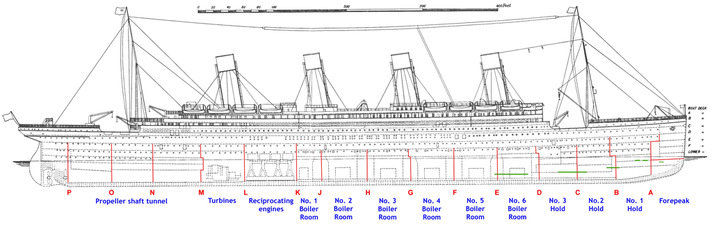

As deck goes from A to G, distance to the staircase increases, which may well have been a factor in survival; it would be useful to retain that information.

We’ll label missing values of `cabin` as `"M"` and treat them as a separate deck.

```r
titanic <- titanic %>%
  mutate(deck = case_when(
    !is.na(cabin) ~ str_extract(cabin, "([A-Z]+)"),
    is.na(cabin) ~ "M",
    .default = NULL)) %>%
  select(deck, everything())
```

To do the above in Python:

```python
titanic['deck'] = titanic['cabin'].apply(lambda x: re.search(r"([A-Z]+)", x).group(0) if pd.notna(x) else "M")
```

If we then create a percent stacked bar chart to look at the distribution of passenger classes across decks:

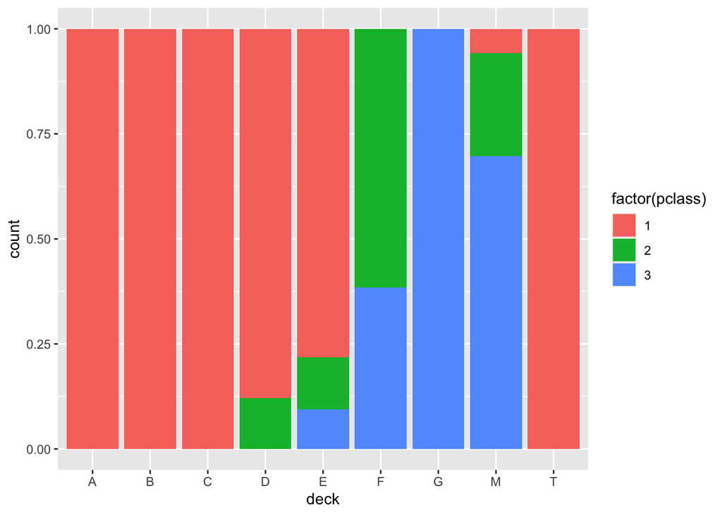

```r
titanic %>%
  ggplot(aes(x = deck, fill = factor(pclass))) +
  geom_bar(position = "fill")
```

In Python:

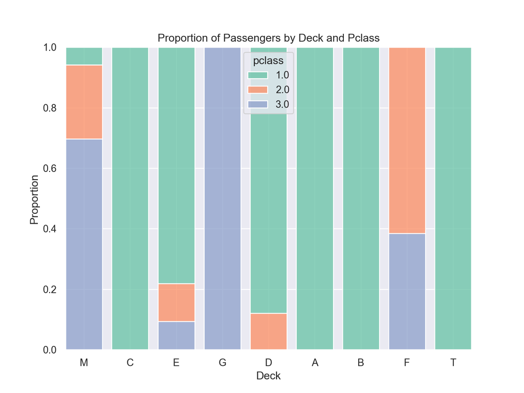

```python
plt.figure(figsize=(8, 6))
sns.histplot(
    data=titanic,
    x='deck',
    hue='pclass',
    multiple='fill',
    shrink=0.8,
    palette="Set2"
)
plt.xlabel("Deck")
plt.ylabel("Proportion")
plt.title("Proportion of Passengers by Deck and Pclass")
plt.show()
```

(Note that Python doesn’t automatically put the levels of the `deck` variable in alphabetical order.)

We might then want to look at the count of observations in each of these categories, to make sure there are no categories with only a very few observations:

```r
titanic %>%
  group_by(deck) %>%
  count()
```

```
# A tibble: 9 × 2
# Groups:   deck [9]
  deck      n
  <chr> <int>
1 A        15
2 B        47
3 C        59
4 D        33
5 E        32
6 F        13
7 G         4
8 M       687
9 T         1
```

There is only one person in the data set in T-deck, and since they are a first-class passenger (and therefore more similar to A-, B-, and C-deck), we’ll group them with A-deck.

We’ll combine A, B, and C decks together, D and E decks together, and F and G decks together. This is because their distributions of passenger classes are relatively similar, and the number of passengers in these decks is relatively low, which might make working with the individual deck membership difficult later on.

We will also now drop `cabin` because we’ve retained the useful information from it.

```r
titanic <- titanic %>%
  mutate(deck = case_when(
    deck == "T" ~ "ABC",
    deck == "A" | deck == "B" | deck == "C" ~ "ABC",
    deck == "D" | deck == "E" ~ "DE",
    deck == "F" | deck == "G" ~ "FG",
    .default = deck)) %>%
  select(-cabin)

titanic %>%
  group_by(deck) %>%
  count()
```

```
# A tibble: 4 × 2
# Groups:   deck [4]
  deck      n
  <chr> <int>
1 ABC     122
2 DE       65
3 FG       17
4 M       687
```

Or in Python:

```python
titanic['deck'] = titanic['deck'].replace({
    'T': 'ABC',
    'A': 'ABC', 'B': 'ABC', 'C': 'ABC',
    'D': 'DE', 'E': 'DE',
    'F': 'FG', 'G': 'FG'
})

# Drop the Cabin column
titanic = titanic.drop(columns=['cabin'])
```

Now there are no missing values left:

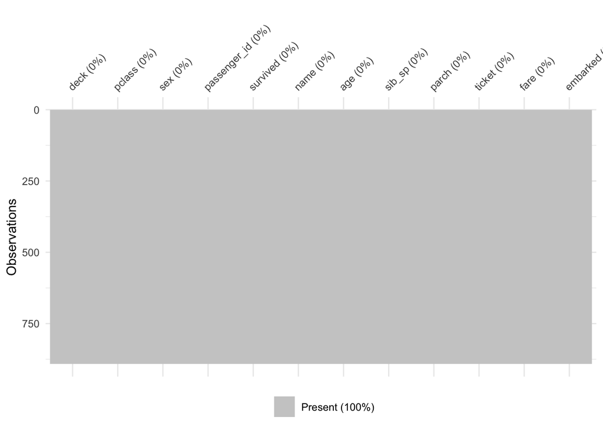

```r
vis_miss(titanic)
```

```r
titanic$embarked %>% is.na() %>%
  mean()
```

```
[1] 0
```

Or in Python:

```python
display_missing(titanic)
```

```
passenger_id column missing values: 0
survived column missing values: 0
pclass column missing values: 0
name column missing values: 0
sex column missing values: 0
age column missing values: 0
sib_sp column missing values: 0
parch column missing values: 0
ticket column missing values: 0
fare column missing values: 0
embarked column missing values: 0
deck column missing values: 0
```

### Initial Split

Now that we’ve dealt with missing data, we’ll split the data into training and testing:

```r
titanic_split <- initial_split(titanic,
                               prop = 0.80,
                               strata = survived)
titanic_train <- training(titanic_split)
titanic_test <- testing(titanic_split)
```

If we preferred to use Python, we could split the data as shown (notice that we are stratifying on the outcome variable, since we know from previous experience that it is imbalanced):

```python
titanic_train, titanic_test = train_test_split(titanic, test_size=0.20, stratify=titanic['survived'])
```

### Continuous Features

For each of the continuous features, we’ll look at their distribution with a histogram and a density curve, broken down by level of the outcome, `survived`.

#### Fare

Here are both those plots for the distribution of `fare`, first in R, then in Python:

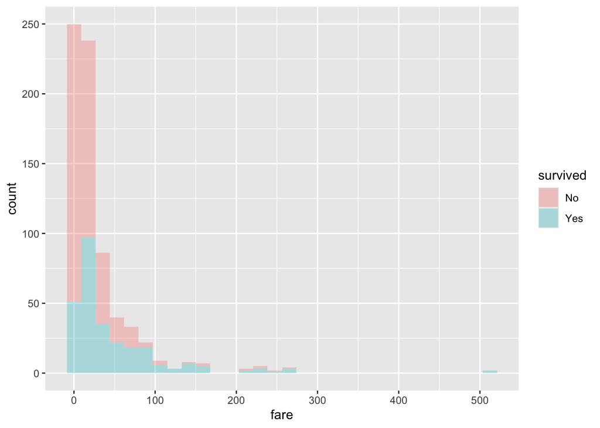

```r
titanic_train %>%
  ggplot(aes(x = fare, fill = survived)) +
  geom_histogram(alpha = 0.3)
```

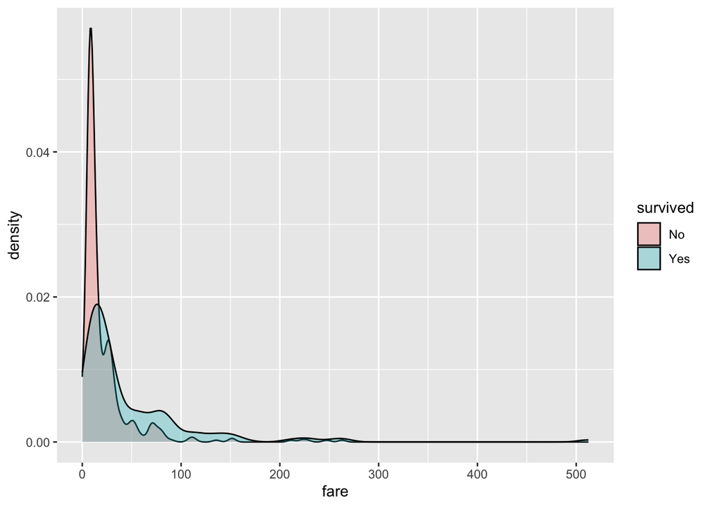

```r
titanic_train %>%
  ggplot(aes(x = fare, fill = survived)) +
  geom_density(alpha = 0.3)
```

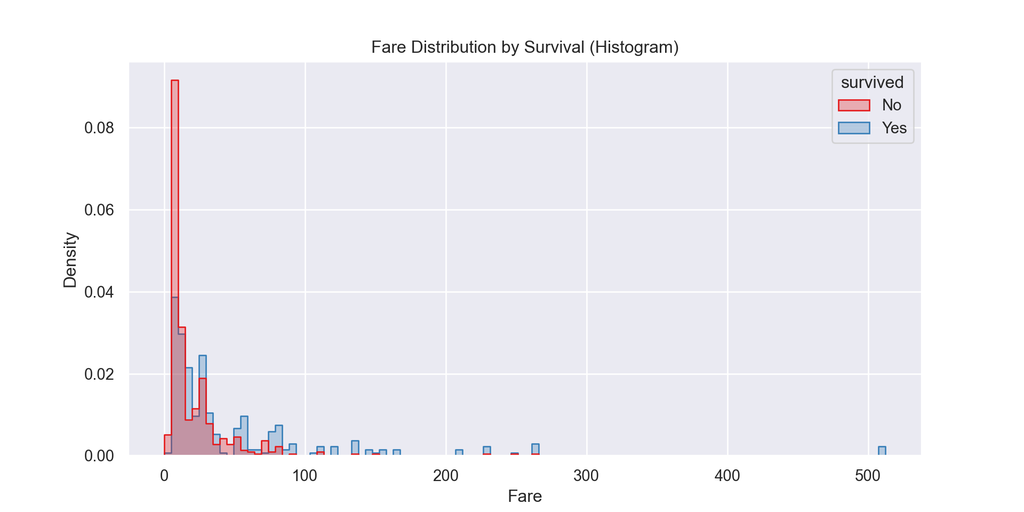

```python
titanic_train['survived'] = titanic_train['survived'].astype('category')

# Histogram plot
plt.figure(figsize=(10, 5))
sns.histplot(
    data=titanic_train,
    x='fare',
    hue='survived',
    element='step',
    stat='density',
    common_norm=False,
    alpha=0.3,
    palette='Set1'
)
plt.title("Fare Distribution by Survival (Histogram)")
plt.xlabel("Fare")
plt.ylabel("Density")
plt.show()
```

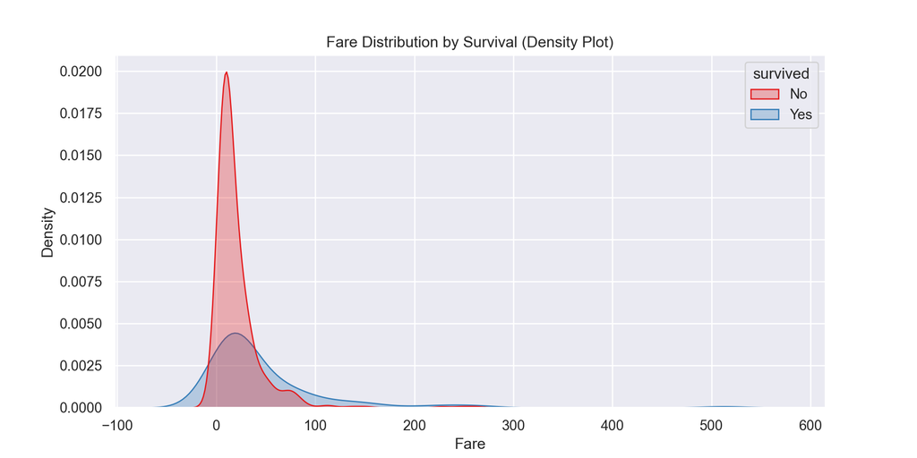

```python
# Density plot
plt.figure(figsize=(10, 5))
sns.kdeplot(
    data=titanic_train,
    x='fare',
    hue='survived',
    fill=True,
    alpha=0.3,
    palette='Set1'
)
plt.title("Fare Distribution by Survival (Density Plot)")
plt.xlabel("Fare")
plt.ylabel("Density")
plt.show()
```

The `fare` feature is positively skewed, and survival rates are very high on the high end. We’ll divide this feature into 13 quantile-based bins. Using quantiles to create the bins will ensure that we have the same number of observations in each group. Creating bins like this does reduce the variability of the feature, but may help models like elastic net pick up on relevant places to split the features. (In practice, it’s worth trying both ways and comparing the cross-validation error for each.)

Here is the distribution of the binned variable, broken down by levels of the outcome:

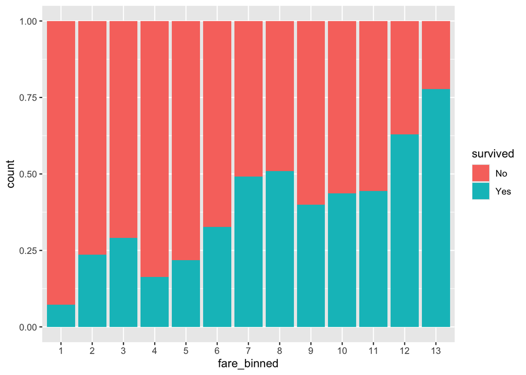

```r
titanic_train <- titanic_train %>%
  mutate(fare_binned = factor(ntile(fare,n=13)))

titanic_train %>%
  ggplot(aes(x = fare_binned, fill = survived)) +
  geom_bar(position = "fill")
```

Or in Python:

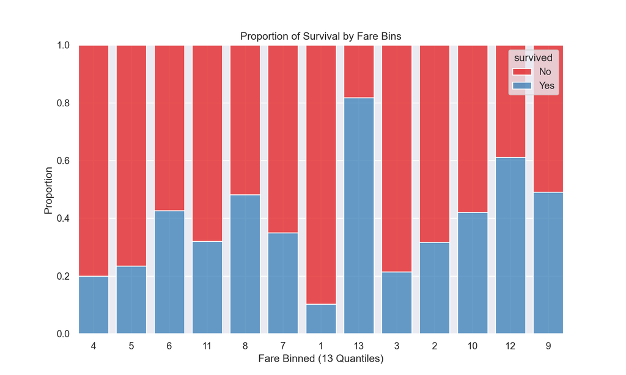

```python
titanic_train['fare_binned'] = pd.qcut(titanic_train['fare'], q=13, labels=False) + 1
titanic_train['fare_binned'] = titanic_train['fare_binned'].astype(str)

plt.figure(figsize=(10, 6))
sns.histplot(
    data=titanic_train,
    x='fare_binned',
    hue='survived',
    multiple='fill',
    shrink=0.8,
    palette='Set1'
)
plt.xlabel("Fare Binned (13 Quantiles)")
plt.ylabel("Proportion")
plt.title("Proportion of Survival by Fare Bins")
plt.show()
```

#### Age

Here are both those plots for the distribution of `age`, first in R, then in Python:

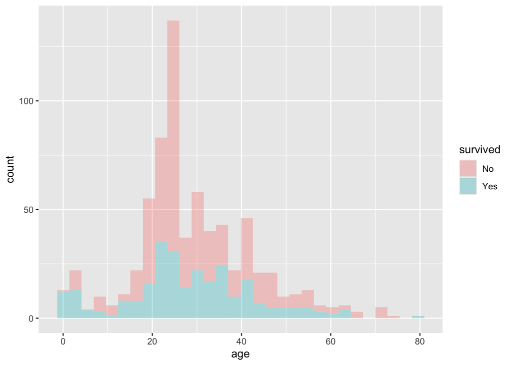

```r
titanic_train %>%
  ggplot(aes(x = age, fill = survived)) +
  geom_histogram(alpha = 0.3)
```

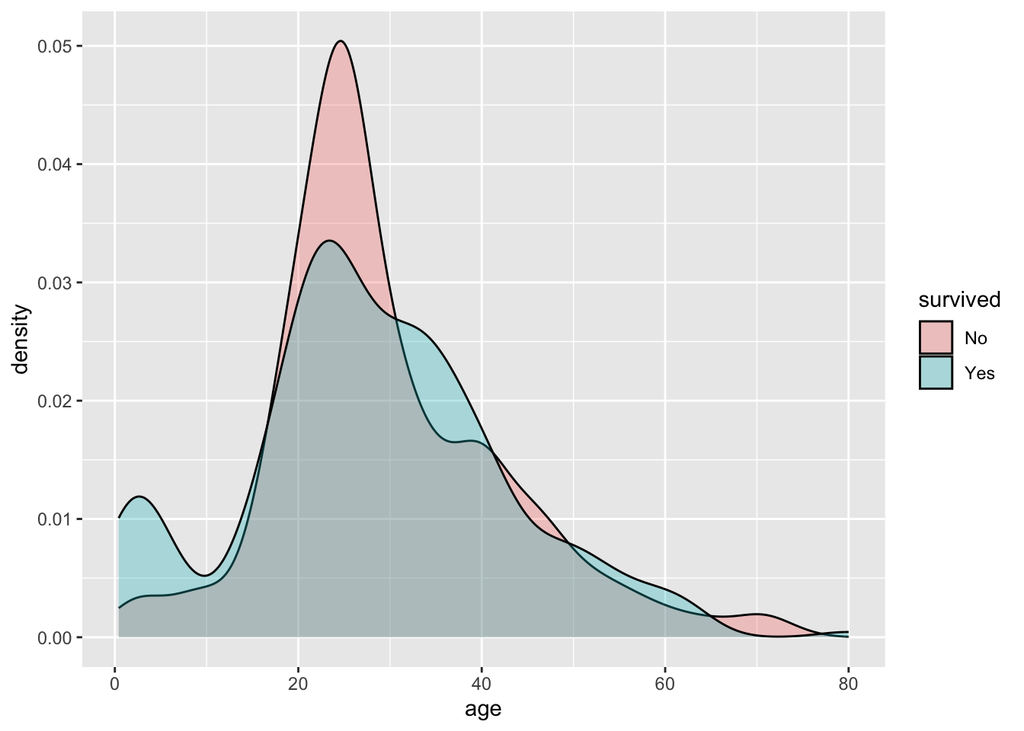

```r
titanic_train %>%
  ggplot(aes(x = age, fill = survived)) +
  geom_density(alpha = 0.3)
```

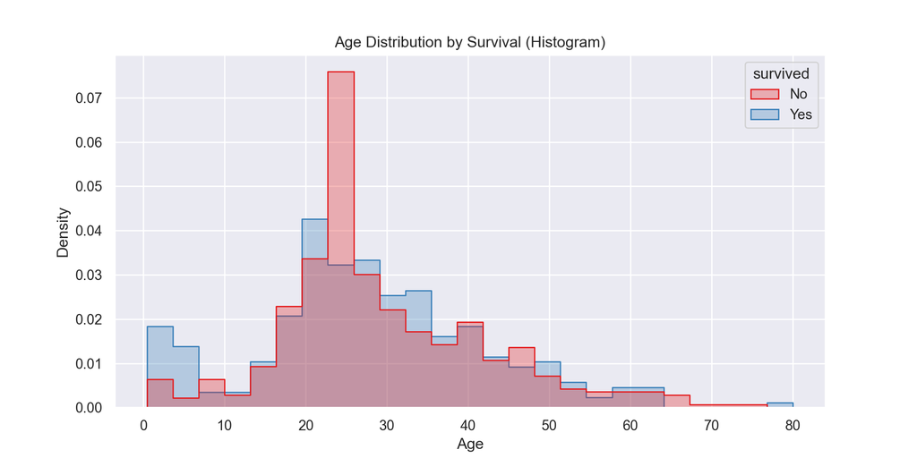

```python
plt.figure(figsize=(10, 5))
sns.histplot(
    data=titanic_train,
    x='age',
    hue='survived',
    element='step',
    stat='density',
    common_norm=False,
    alpha=0.3,
    palette='Set1'
)
plt.title("Age Distribution by Survival (Histogram)")
plt.xlabel("Age")
plt.ylabel("Density")
plt.show()
```

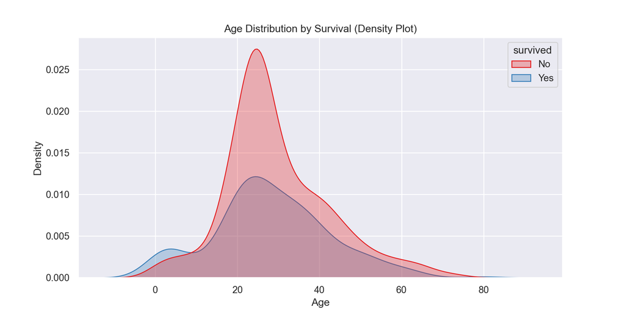

```python
# Density plot
plt.figure(figsize=(10, 5))
sns.kdeplot(
    data=titanic_train,
    x='age',
    hue='survived',
    fill=True,
    alpha=0.3,
    palette='Set1'
)
plt.title("Age Distribution by Survival (Density Plot)")
plt.xlabel("Age")
plt.ylabel("Density")
plt.show()
```

This variable is not really normally distributed, but it also isn’t extremely skewed. We could attempt to apply a transformation to bring the distribution closer to normal, or we could leave it as is. Another option would be to bin this variable. We’ll choose to leave it as is.

### Categorical Features

#### Family Size

Let’s consolidate the information from the two variables `sib_sp` and `parch` into one, creating a new variable that we’ll call `family_size`. We can sum `sib_sp` and `parch`, then add one to represent the individual themselves. After doing so, looking at a bar chart reveals that there are a number of family sizes with very few observations, so it may make more sense to re-code the variable into `Alone`, `Small`, `Medium`, and `Large`, as shown below.

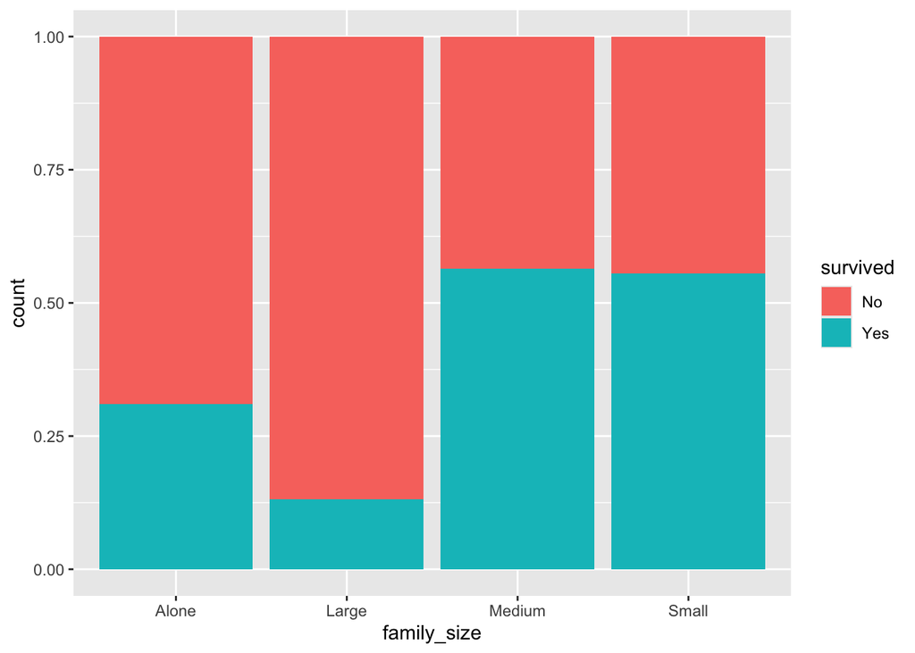

```r
titanic_train <- titanic_train %>%
  mutate(family_size = sib_sp + parch + 1) %>%
  mutate(family_size = case_when(
    family_size == 1 ~ "Alone",
    family_size >= 2 & family_size <= 3 ~ "Small",
    family_size >= 4 & family_size <= 5 ~ "Medium",
    family_size >= 6 ~ "Large"
  ))

titanic_train %>%
  ggplot(aes(x = family_size, fill = survived)) +
  geom_bar(position = "fill")
```

Or in Python:

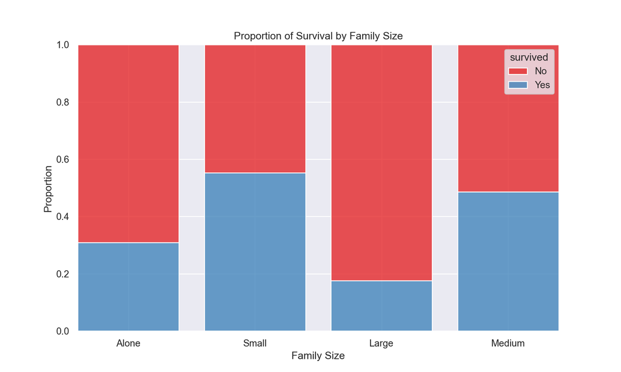

```python
titanic_train['family_size'] = titanic_train['sib_sp'] + titanic_train['parch'] + 1

# Categorize family size
def categorize_family_size(size):
    if size == 1:
        return "Alone"
    elif 2 <= size <= 3:
        return "Small"
    elif 4 <= size <= 5:
        return "Medium"
    else:
        return "Large"

titanic_train['family_size'] = titanic_train['family_size'].apply(categorize_family_size)

# Plot the bar chart
plt.figure(figsize=(10, 6))
sns.histplot(
    data=titanic_train,
    x='family_size',
    hue='survived',
    multiple='fill',
    shrink=0.8,
    palette='Set1'
)
plt.xlabel("Family Size")
plt.ylabel("Proportion")
plt.title("Proportion of Survival by Family Size")
plt.show()
```

Interestingly, members of large families were less likely to survive, as were passengers traveling with no family members. Members of medium and small families were more likely to survive. It may be that the bigger the family, the more likely the family had children, and children were prioritized for rescue – however, that doesn’t explain the drop in survival chances for members of large families.

#### Ticket Size

It might seem redundant to make another feature using the information from `ticket`, but this variable may capture additional information. Not all passengers on the Titanic were traveling with family members. Many, like the example in the “missing data” section, traveled with servants or staff, who were listed on the same ticket with them but not counted as family members.

Here we create a variable called `ticket_size` and look at the relationship between it and `survived`.

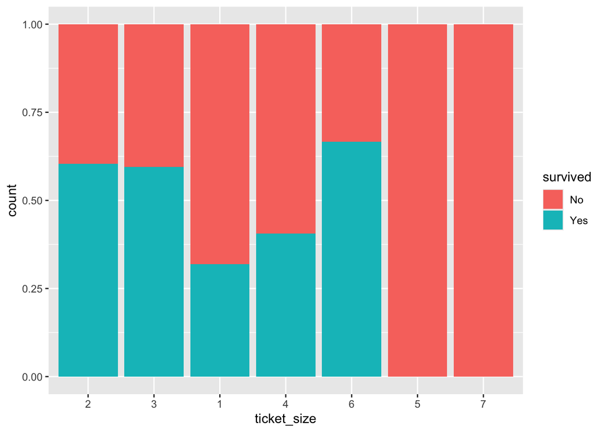

```r
titanic_train <- titanic_train %>%
  group_by(ticket) %>%
  reframe(ticket_size = factor(n()),
            across(.cols = everything()))

titanic_train %>%
  ggplot(aes(x = ticket_size, fill = survived)) +
  geom_bar(position = "fill")
```

Or in Python:

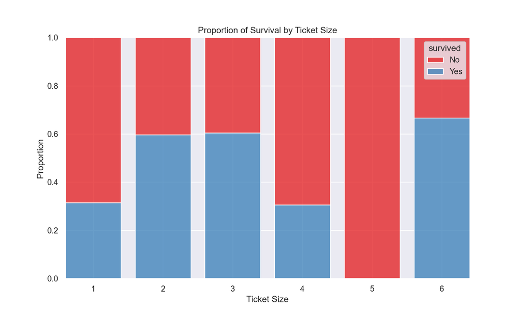

```python
ticket_sizes = titanic_train.groupby('ticket').size().reset_index(name='ticket_size')

titanic_train = titanic_train.merge(ticket_sizes, on='ticket')

titanic_train['ticket_size'] = titanic_train['ticket_size'].astype('category')

plt.figure(figsize=(10, 6))
sns.histplot(
    data=titanic_train,
    x='ticket_size',
    hue='survived',
    multiple='fill',
    shrink=0.8,
    palette='Set1'
)
plt.xlabel("Ticket Size")
plt.ylabel("Proportion")
plt.title("Proportion of Survival by Ticket Size")
plt.show()
```

#### Title

There is very likely to be some useful information in the `name` variable, although it is trickier to access.

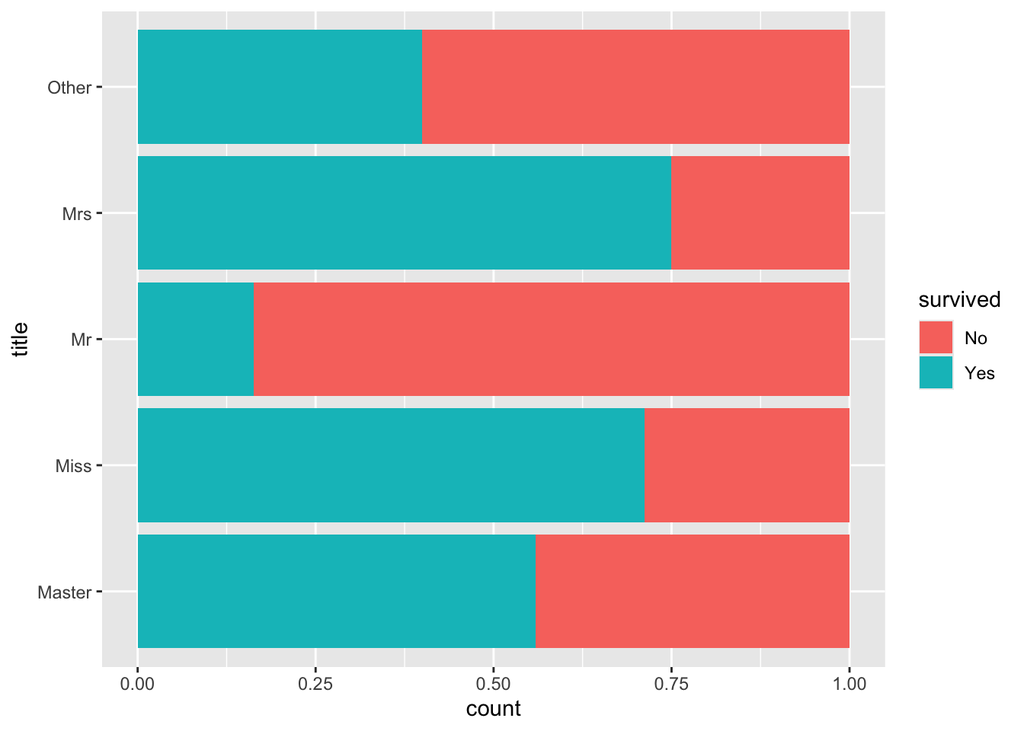

```r
titanic_train <- titanic_train %>%
  mutate(title = (str_split(titanic_train$name, ",") %>%
  str_extract("[A-Za-z]+\\.") %>%
  str_remove("\\."))) %>%
  mutate(title = fct_lump(title, n = 4))

titanic_train %>%
  ggplot(aes(y = title, fill = survived)) + geom_bar(position = "fill")
```

Or in Python:

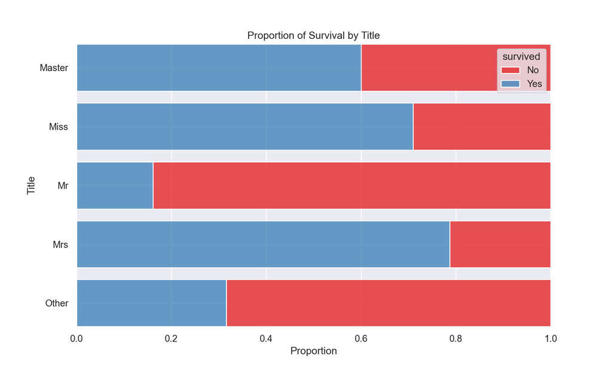

```python
titanic_train['title'] = titanic_train['name'].apply(lambda x: re.search(r",\s*(.*?)(\.|$)", x).group(1) if re.search(r",\s*(.*?)(\.|$)", x) else None)

title_counts = titanic_train['title'].value_counts()

top_titles = title_counts.nlargest(4).index
titanic_train['title'] = titanic_train['title'].where(titanic_train['title'].isin(top_titles), 'Other')

titanic_train['title'] = titanic_train['title'].astype('category')

plt.figure(figsize=(10, 6))
sns.histplot(
    data=titanic_train,
    y='title',
    hue='survived',
    multiple='fill',
    shrink=0.8,
    palette='Set1'
)
plt.ylabel("Title")
plt.xlabel("Proportion")
plt.title("Proportion of Survival by Title")
plt.show()
```

Older men (with titles of Mr. rather than Master) were the least likely to survive, while married women (with titles of Mrs.) were the most likely.

### Finalized Dataset

In R, we don’t need to manually dummy-code (or one-hot encode) the categorical features or transform the outcome variable, because `tidymodels` provides us with recipe steps we can use.

In Python, however, we need to dummy-code the features and re-code the target ourselves. Here I provide the code to do this.

We should make sure to remember to apply all the feature engineering done above to both the training and the testing set.

```r
titanic_train <- titanic_train %>%
  select(-c(ticket, passenger_id, name, sib_sp,
            parch, fare)) %>%
  mutate(survived = factor(survived))

titanic_test <- titanic_test %>%
  mutate(fare_binned = factor(ntile(fare,n=13))) %>%
  mutate(family_size = sib_sp + parch + 1) %>%
  mutate(family_size = case_when(
    family_size == 1 ~ "Alone",
    family_size >= 2 & family_size <= 3 ~ "Small",
    family_size >= 4 & family_size <= 5 ~ "Medium",
    family_size >= 6 ~ "Large"
  )) %>%
  group_by(ticket) %>%
  reframe(ticket_size = factor(n()),
            across(.cols = everything())) %>%
  mutate(title = (str_split(titanic_test$name, ",") %>%
  str_extract("[A-Za-z]+\\.") %>%
  str_remove("\\."))) %>%
  mutate(title = fct_lump(title, n = 4)) %>%
  select(-c(ticket, passenger_id, name, sib_sp,
            parch, fare))

titanic_recipe <- recipe(survived ~ .,
                         data = titanic_train) %>%
  step_dummy(all_nominal_predictors(), one_hot = TRUE)

prep(titanic_recipe) %>%
  bake(titanic_train)
```

```
# A tibble: 712 × 41
   pclass   age survived ticket_size_X2 ticket_size_X3 ticket_size_X1
    <dbl> <dbl> <fct>             <dbl>          <dbl>          <dbl>
 1      1    30 Yes                   1              0              0
 2      1    33 Yes                   1              0              0
 3      1    52 No                    0              1              0
 4      1    39 Yes                   0              1              0
 5      1    18 Yes                   0              1              0
 6      1    47 No                    1              0              0
 7      1    40 No                    1              0              0
 8      1    60 Yes                   0              0              1
 9      1    47 No                    0              0              1
10      1    44 Yes                   0              0              1
# ℹ 702 more rows
# ℹ 35 more variables: ticket_size_X4 <dbl>, ticket_size_X6 <dbl>,
#   ticket_size_X5 <dbl>, ticket_size_X7 <dbl>, deck_ABC <dbl>, deck_DE <dbl>,
#   deck_FG <dbl>, deck_M <dbl>, sex_female <dbl>, sex_male <dbl>,
#   embarked_C <dbl>, embarked_Q <dbl>, embarked_S <dbl>, fare_binned_X1 <dbl>,
#   fare_binned_X2 <dbl>, fare_binned_X3 <dbl>, fare_binned_X4 <dbl>,
#   fare_binned_X5 <dbl>, fare_binned_X6 <dbl>, fare_binned_X7 <dbl>, …
```

```r
prep(titanic_recipe) %>%
  bake(titanic_test)
```

```
# A tibble: 179 × 41
   pclass   age survived ticket_size_X2 ticket_size_X3 ticket_size_X1
    <dbl> <dbl> <fct>             <dbl>          <dbl>          <dbl>
 1      1    16 Yes                   0              0              1
 2      1    28 Yes                   0              0              1
 3      1    61 No                    0              0              1
 4      1    16 Yes                   0              0              1
 5      1    35 Yes                   0              0              1
 6      1    40 Yes                   0              0              1
 7      1    28 No                    0              0              1
 8      1    35 Yes                   0              0              1
 9      1    65 No                    0              0              1
10      1    11 Yes                   0              0              1
# ℹ 169 more rows
# ℹ 35 more variables: ticket_size_X4 <dbl>, ticket_size_X6 <dbl>,
#   ticket_size_X5 <dbl>, ticket_size_X7 <dbl>, deck_ABC <dbl>, deck_DE <dbl>,
#   deck_FG <dbl>, deck_M <dbl>, sex_female <dbl>, sex_male <dbl>,
#   embarked_C <dbl>, embarked_Q <dbl>, embarked_S <dbl>, fare_binned_X1 <dbl>,
#   fare_binned_X2 <dbl>, fare_binned_X3 <dbl>, fare_binned_X4 <dbl>,
#   fare_binned_X5 <dbl>, fare_binned_X6 <dbl>, fare_binned_X7 <dbl>, …
```

```python
# Process the training dataset
titanic_train = titanic_train.drop(columns=['ticket', 'passenger_id', 'name', 'sib_sp', 'parch', 'fare'])
titanic_train['survived'] = titanic_train['survived'].astype('category')

titanic_train['survived'] = titanic_train['survived'].map({'Yes': 1, 'No': 0})

# Process the test dataset
titanic_test['fare_binned'] = pd.qcut(titanic_test['fare'], q=13, labels=False) + 1

titanic_test['family_size'] = titanic_test['sib_sp'] + titanic_test['parch'] + 1

def categorize_family_size(size):
    if size == 1:
        return "Alone"
    elif 2 <= size <= 3:
        return "Small"
    elif 4 <= size <= 5:
        return "Medium"
    else:
        return "Large"

titanic_test['family_size'] = titanic_test['family_size'].apply(categorize_family_size)

ticket_sizes = titanic_test.groupby('ticket').size().reset_index(name='ticket_size')
titanic_test = titanic_test.merge(ticket_sizes, on='ticket')

titanic_test['ticket_size'] = titanic_test['ticket_size'].astype('category')

titanic_test['title'] = titanic_test['name'].apply(lambda x: re.search(r",\s*(.*?)(\.|$)", x).group(1) if re.search(r",\s*(.*?)(\.|$)", x) else None)

title_counts = titanic_test['title'].value_counts()

top_titles = title_counts.nlargest(4).index
titanic_test['title'] = titanic_test['title'].where(titanic_test['title'].isin(top_titles), 'Other')

titanic_test['title'] = titanic_test['title'].astype('category')

titanic_test = titanic_test.drop(columns=['ticket', 'passenger_id', 'name', 'sib_sp', 'parch', 'fare'])

# One-hot encode categorical features for training and test sets
titanic_train = pd.get_dummies(titanic_train, drop_first=False)
titanic_test = pd.get_dummies(titanic_test, drop_first=False)

# Align columns of training and testing data to ensure they have the same feature set
titanic_train, titanic_test = titanic_train.align(titanic_test, join='outer', axis=1, fill_value=0)

# Show final datasets
print(titanic_train.head())
```

```
    age  deck_ABC  deck_DE  ...  title_Mr  title_Mrs  title_Other
0  25.0     False    False  ...      True      False        False
1  25.0     False    False  ...      True      False        False
2  30.0     False    False  ...     False      False        False
3  33.0     False    False  ...      True      False        False
4  36.0     False     True  ...      True      False        False

[5 rows x 44 columns]
```

```python
print(titanic_test.head())
```

```
    age  deck_ABC  deck_DE  ...  title_Mr  title_Mrs  title_Other
0  40.0      True    False  ...      True      False        False
1  22.0     False    False  ...      True      False        False
2  34.0     False    False  ...      True      False        False
3  38.0      True    False  ...     False       True        False
4  52.0     False     True  ...     False       True        False

[5 rows x 44 columns]
```